# Expressed Variant Reporting

Brandon Michael Blobner, Jenny Leopoldina Smith, and Ahmad Al Khleifat

2021-04-03

# 1 About The Test: Variant Detection from RNA-seq

[figure not shown]

snpReportR

Patient details:

| Information | Value |
| --- | --- |
| Name: | Jane Doe |
| DOB: | 01/01/1900 |
| Sex: | F |
| Sample Type: | RNA |

Test ordered by:

| Information | Value |
| --- | --- |
| Name: | Dr.X |
| Doctor identification number: | 12345 |
| Hospital: | NCI |

This document will help you to understand the more important findings from a gene variant screening. The common definitions of the type of genetic variants (mutations) are described in the figure and in the table in section `Chromosome and Gene Vizualization of Mutations`.

While a variant may have been detected, the associations with the variant are not perfectly causal and their complex interactions between biology and the environment.

# 2 About the Dataset

|  | Number | Type | Description |
| --- | --- | --- | --- |
| AC | A | Integer | Allele count in genotypes for each ALT allele in the same order as listed |
| AF | A | Float | Allele Frequency for each ALT allele in the same order as listed |
| AN | 1 | Integer | Total number of alleles in called genotypes |
| ANN | . | String | Functional annotations: 'Allele \| Annotation \| Annotation_Impact \| Gene_Name \| Gene_ID \| Feature_Type \| Feature_ID \| Transcript_BioType \| Rank \| HGVS.c \| HGVS.p \| cDNA.pos / cDNA.length \| … |
| BaseQRankSum | 1 | Float | Z-score from Wilcoxon rank sum test of Alt Vs. Ref base qualities |
| COSMIC_ID | . | String | COSMIC mutation id (unique). |
| DP | 1 | Integer | Approximate read depth; some reads may have been filtered |
| Entropy | 1 | Float | Entropy for sequence in window of length 7 centered at the variant position |
| ExcessHet | 1 | Float | Phred-scaled p-value for exact test of excess heterozygosity |
| FATHMM | . | String | FATHMM (Functional Analysis through Hidden Markov Models). 'Pathogenic':Cancer or damaging 'Neutral':Passanger or Tolerated. |

[output cut: 50 more lines]

Table 1. Column names and Descriptions

*In addition there are functional annotations for the variants per transcript from snpEFF. These include:*

- “Annotation_Impact”
- “Feature_Type”
- “Transcript_BioType”
- “Rank”
- “HGVS.c”
- “HGVS.p”
- “cDNA.pos/cDNA.length”
- “CDS.pos/CDS.length”
- “AA.pos/AA.length”
- “Distance”

*The top variants were ranked by the following attributes:*

- FATHMM predicted pathogenicty or splice adjacent
- CHASMplus predicts driver mutations
- genes with larger number of SNVs prioritized
- high or moderate impact on the structure of the gene
- CADD Score/Polyphen Score (not done yet)

*Interpretation of attributes*

- “[FATHMM] weighted algorithm is capable of adjusting our conservation-based predictions to account for the tolerance of related sequences to mutations” (http://fathmm.biocompute.org.uk/inherited.html)
- “CHASMplus scores range from 0 to 1, with higher scores meaning more likely to be a cancer driver mutation.” (https://chasmplus.readthedocs.io/en/latest/)
- “VEST‐indel scores were assigned to categories of pathogenic (≥0.5) or benign (<0.5).” (https://doi.org/10.1002/humu.22911)

|  | FATHMM | SPLICEADJ | Annotation_Impact_1 | Number_of_Genes |
| --- | --- | --- | --- | --- |
| 1 | PATHOGENIC |  | MODERATE | 7 |

# 3 HumanMine Annotation for Further Results

```
## [1] "COPA"    "PYCRL"   "FCHSD2"  "FSCN1"   "DCUN1D5"
```

|  | COPA.Top.Expression | DCUN1D5.Top.Expression | FCHSD2.Top.Expression | FSCN1.Top.Expression | PYCRL.Top.Expression |
| --- | --- | --- | --- | --- | --- |
| 1 | smooth muscle | colon | duodenum | cerebral cortex | B-cells |
| 2 | pancreas | ovary | liver | smooth muscle | cerebral cortex |
| 3 | prostate | skin | epididymis | tonsil | fallopian tube |
| 4 | placenta | duodenum | spleen | fallopian tube | dendritic cells |
| 5 | endometrium | small intestine | monocytes | thyroid gland | thyroid gland |

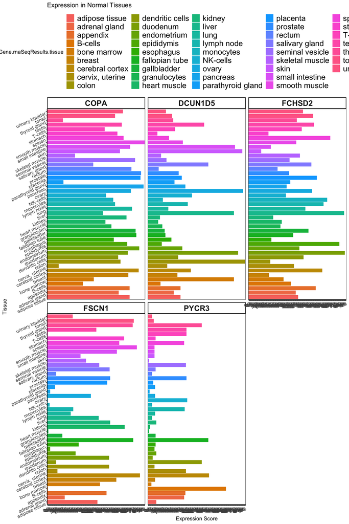

Expression of Genes with identified variants/SNVs in Normal Tissues.

# 4 Results Table

Included here are two tables for different gene types. Coding refers to genes that produce proteins, while non-coding refers to genes which do get utilized to produce proteins.

## 4.1 Coding Genes

|  | GENE | Number_SNVs_per_Gene | COSMIC_ID | rsID | CHROM | POS | ID | REF | ALT | FATHMM | SPLICEADJ | chasmplus_pval | chasmplus_score | vest_pval | vest_score | TISSUE | TUMOR | Annotation_1 | Annotation_Impact_1 | Feature_Type_1 | Transcript_BioType_1 | coding_DNA_change_1 | protein_change_1 |
| --- | --- | --- | --- | --- | --- | --- | --- | --- | --- | --- | --- | --- | --- | --- | --- | --- | --- | --- | --- | --- | --- | --- | --- |
| 1 | COPA | 1 | COSV54106499 |  | chr1 | 160314071 |  | C | T | PATHOGENIC |  | 0.0606 | 0.186 | 0.01255 | 0.884 | endometrium | carcinoma_--_endometrioid_carcinoma | missense_variant | MODERATE | transcript | Coding | c.761G&gt;A | p.Cys254Tyr |
| 2 | PYCRL | 1 | COSV55307994 |  | chr8 | 143606115 |  | T | G | PATHOGENIC |  | 0.217 | 0.091 | 0.10515 | 0.639 | lung | carcinoma_--_adenocarcinoma | missense_variant | MODERATE | transcript | Coding | c.625A&gt;C | p.Lys209Gln |
| 3 | FCHSD2 | 1 | COSV60815003 |  | chr11 | 72849810 |  | G | C | PATHOGENIC |  | 0.248 | 0.081 | 0.04089 | 0.776 | lung | carcinoma_--_adenocarcinoma | missense_variant | MODERATE | transcript | Coding | c.1388C&gt;G | p.Pro463Arg |
| 4 | FSCN1 | 1 | COSV61019122 |  | chr7 | 5605437 |  | C | T | PATHOGENIC |  | 0.412 | 0.046 |  |  | lung | carcinoma_--_adenocarcinoma | missense_variant | MODERATE | transcript | Coding | c.1445C&gt;T | p.Ala482Val |
| 5 | DCUN1D5 | 1 | COSV52783741 |  | chr11 | 103066337 |  | T | C | PATHOGENIC |  | 0.538 | 0.03 | 0.07216 | 0.702 | endometrium | carcinoma_--_endometrioid_carcinoma | missense_variant | MODERATE | transcript | Coding | c.487A&gt;G | p.Lys163Glu |
| 6 | MTM1 | 1 | COSV60338001 |  | chrX | 150598610 |  | T | C | PATHOGENIC |  | 0.65 | 0.02 | 0.16567 | 0.538 | skin | malignant_melanoma_--_NS | missense_variant | MODERATE | transcript | Coding | c.155T&gt;C | p.Ile52Thr |
| 7 | BCCIP | 1 | COSV53395393 |  | chr10 | 125823663 |  | G | A | PATHOGENIC |  | 0.737 | 0.014 | 0.38852 | 0.274 | soft_tissue | rhabdomyosarcoma_--_embryonal | missense_variant | MODERATE | transcript | Coding | c.106G&gt;A | p.Asp36Asn |

## 4.2 Non-Coding Genes

|  | GENE | Number_SNVs_per_Gene | COSMIC_ID | rsID | CHROM | POS | ID | REF | ALT | FATHMM | SPLICEADJ | chasmplus_pval | chasmplus_score | vest_pval | vest_score | TISSUE | TUMOR | Annotation_1 | Annotation_Impact_1 | Feature_Type_1 | Transcript_BioType_1 | coding_DNA_change_1 | protein_change_1 |
| --- | --- | --- | --- | --- | --- | --- | --- | --- | --- | --- | --- | --- | --- | --- | --- | --- | --- | --- | --- | --- | --- | --- | --- |

# 5 Chromosome and Gene Vizualization of Mutations

Table 6. Types of Expressed Variants

| Type | Description |
| --- | --- |
| coding: | Mutation is within a coding region |
| 5prime_UTR: | Mutation is within 5’ untranslated region |
| 3prime_UTR: | Mutation is with 3’ untranslated region |
| introninc: | Mutation is with an intron region |
| splice: | Mutation is within proximity to a splice-site. |
| synonymous_variant: | Synonymous variant is a mutation in an exon that results in same amino acid (changed codon) |
| missense_variant: | Missense variant is a mutation in an exon that results in a different amino acid (changed codon) |
| start/stop: | Mutation is within a start/stop codon. |

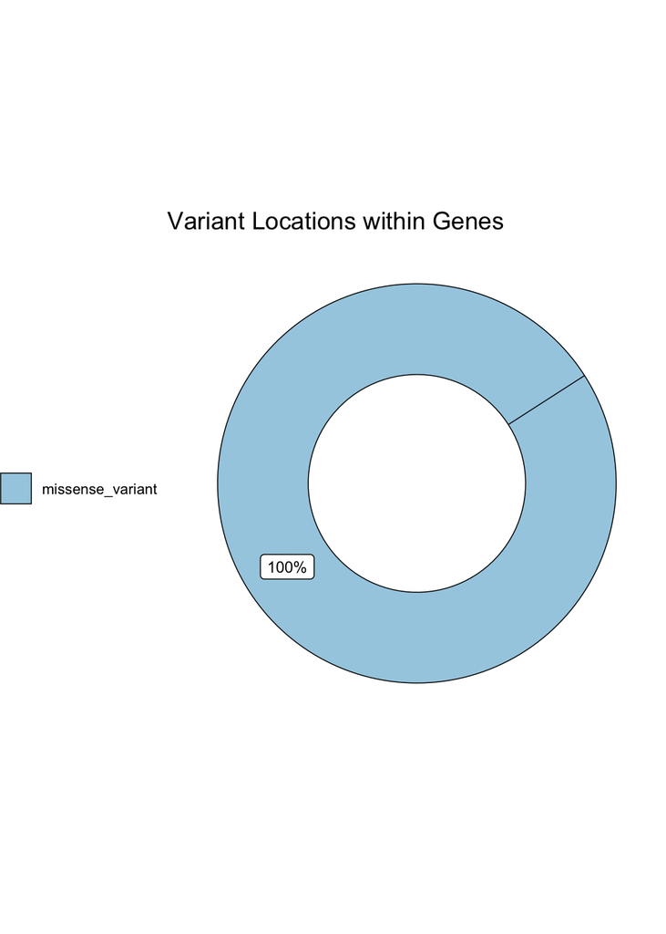

Figure 1. Percentage of different types of mutations identified.

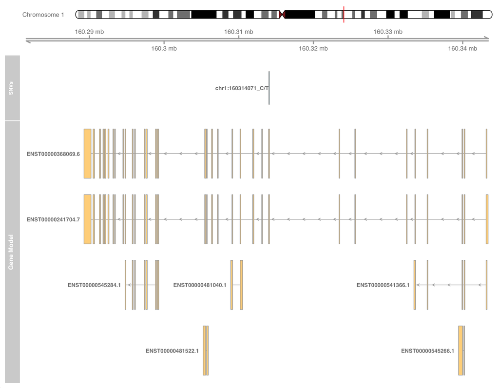

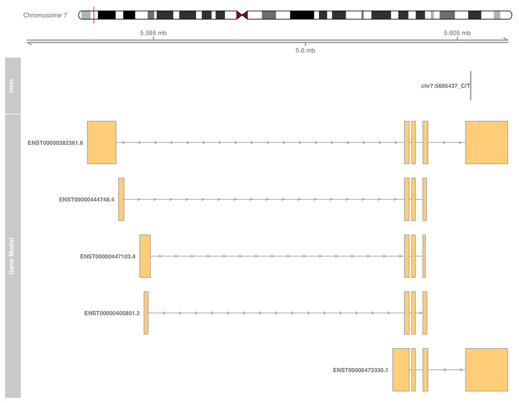

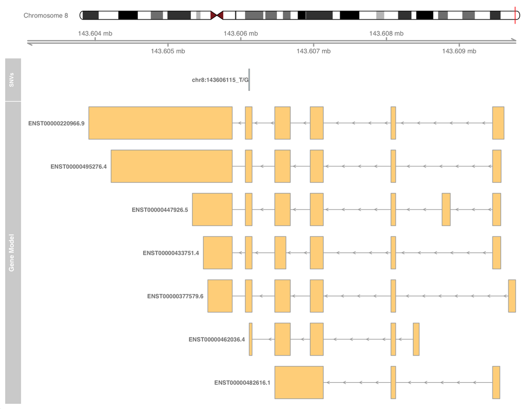

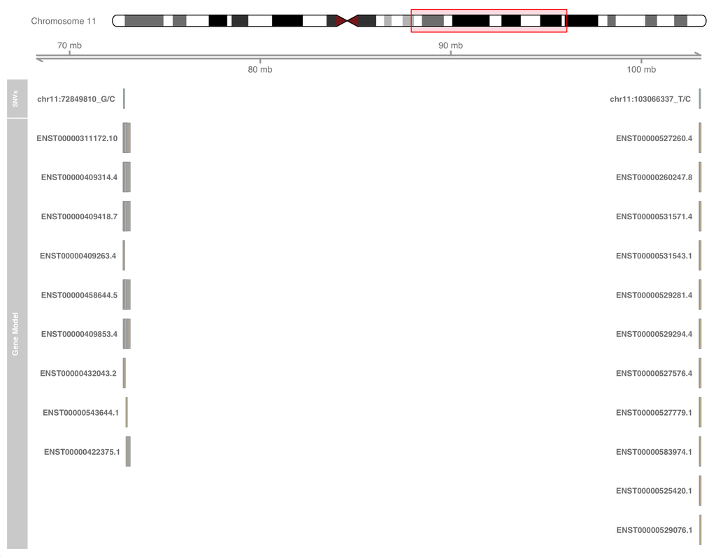

```r
# Add Lollipop plot - interactive
```

# 6 Expression of Genes with Mutations

# 7 boxplots/violin plots

```r
# sample <- params$Sample cts_file <- dir('Data/',
# pattern=sample) counts <- read.csv(cts_file)
```

# 8 DE genes by condition

```r
# DE_file <- dir('Data/', pattern=sample) Read in
# differntial expression results
diff.ex <- read.table(here::here(params$degs), header = T)

# Filter significant results
diff.ex <- diff.ex[which(diff.ex$PValue < 0.05), ]

# Sort significant results by log fold change
diff.ex <- diff.ex[order(diff.ex$logFC, decreasing = T),
    ]

# Extract top (greatest logFC) five upregulated and
# downregulated genes
top.diff.ex.up <- head(diff.ex, n = 5)
top.diff.ex.down <- tail(diff.ex, n = 5)
top.diff.ex <- rbind(top.diff.ex.up, top.diff.ex.down)

# Extract gene ID
gene.names <- top.diff.ex[, 1]
```

# 9 Sommelier results: Haplyotype/PCA

```r
# add results here
```

# 10 What Does This Result Mean for you? And What’s Next?

Genetic tests sometimes reveal information that could be relevant to your family such as a health risk that might run in the family, or that family relationships are different from what you expected.

1. how your family members may be affected if the test shows a serious health condition runs in your family.
2. the risk of you and your partner passing on a health condition to your children your options if you have a child with an inherited health condition and you do not want your next child to inherit it
3. genetic counsellor can also direct you to relevant patient support group

```r
# Need diagram here
```

# 11 More information

## 11.1 Recent Publications

|  | Gene.publications.pubMedId | Gene.publications.firstAuthor | Gene.publications.year |
| --- | --- | --- | --- |
| 1 | 31980649 | Kennedy Susan A | 2020 |
| 2 | 32203420 | Müller Paul M | 2020 |
| 3 | 32877691 | Antonicka Hana | 2020 |
| 4 | 33005030 | Chen Yanke | 2020 |
| 5 | 32325033 | Pourhaghighi Reza | 2020 |
| 6 | 32296183 | Luck Katja | 2020 |
| 7 | 32814053 | Haenig Christian | 2020 |
| 8 | 32325033 | Pourhaghighi Reza | 2020 |
| 9 | 31253590 | Hüttenhain Ruth | 2019 |
| 10 | 31452512 | Pech Matthew F | 2019 |

[output cut: 15 more lines]

## 11.2 Potential Drug Targets

Can search for additional drugs that may target the mutant genes online using [Drug Targetor](http://drugtargetor.com/) and at [Drug Gene Interaction Database](https://www.dgidb.org/)

```r
# add drug target data information
```

## 11.3 Potential Clinical Trials

```r
# search API at https://clinicaltrials.gov/api/
```

## 11.4 Web resources

```r
# Add QR code where does it go?
```

# 12 Consent for Analysis

This should simply be a copy of the consent form the patient has already signed. Also, interactive shiny widgets make this less portable.

```r
# Need to have runtime: shiny in the YAML header
# but this makes the Rmd essentially a shiny server
# which limits portability AFAIK
# patient_signature()
```

# 13 Quality Control

## 13.1 Embed the IGV output from CTAT Mutation pipeline.

```r
# embed file here
```

## 13.2 Sequencing Depth and QC

```r
# include Deeptools plots for coverage, average
# base quality scores, alignment quality scores,
# etc.
```

# 14 References:

## 14.1 Citations

*Smith RN, et al. InterMine: a flexible data warehouse system for the integration and analysis of heterogeneous biological data. Bioinformatics. 2012 Dec 1;28(23):3163-5.*

## 14.2 Genome References and Software

## 14.3 Additional information about the pipelines used, check out the github repositories listed below:

- [CTAT Mutation Pipeline for Input VCF](https://github.com/collaborativebioinformatics/expressed-variant-impact)
- [Association between Genes and Drug Targets](https://github.com/collaborativebioinformatics/viravate2)
- [Mixed Sample Graphs QC](https://github.com/collaborativebioinformatics/mixed-sample-graphs)
- [snpReportR Generation](https://github.com/collaborativebioinformatics/expressed-variant-reporting)
- [CHASMplus](https://chasmplus.readthedocs.io/en/latest/index.html)
- [FATHMM](http://fathmm.biocompute.org.uk/)
- [VEST](https://karchinlab.org/apps/appVest.html)

|  | Value | Value.1 | Value.2 | GATKCommandLine.CommandLine | GATKCommandLine.Version | GATKCommandLine.Date |
| --- | --- | --- | --- | --- | --- | --- |
| 1 | "SnpEff -nostats -noLof -no-downstream -no-upstream hg38 " | "4.1k (build 2015-09-07), by Pablo Cingolani" | VCFv4.2 | "HaplotypeCaller --standard-min-confidence-threshold-for-calling 20.0 --recover-dangling-heads true --dont-use-soft-clipped-bases true --output /home/dnanexus/OUTDIR/work_dir/chr1.interval.vcf --inter… | "4.1.7.0" | "January 8, 2021 at 5:14:42 PM GMT" |
| 2 | "SnpEff -nostats -noLof -no-downstream -no-upstream hg38 " | "4.1k (build 2015-09-07), by Pablo Cingolani" | VCFv4.2 | "SelectVariants --output /home/dnanexus/OUTDIR/work_dir/HaplotypeCaller.hard_cutoff_filters_applied.selected_variants.vcf --exclude-filtered true --select-type-to-include SNP --variant /home/dnanexus/… | "4.1.7.0" | "January 8, 2021 at 5:25:01 PM GMT" |

```
## TxDb object:
## # Db type: TxDb
## # Supporting package: GenomicFeatures
## # Data source: ~/Downloads/gencode.v22.annotation.gtf.gz
## # Organism: NA
## # Taxonomy ID: NA
## # miRBase build ID: NA
## # Genome: NA
## # Nb of transcripts: 198442
## # Db created by: GenomicFeatures package from Bioconductor
## # Creation time: 2021-03-30 19:49:41 -0700 (Tue, 30 Mar 2021)
## # GenomicFeatures version at creation time: 1.42.2
## # RSQLite version at creation time: 2.2.5
## # DBSCHEMAVERSION: 1.2
```